# **Nitinat in-season update**

Last update: 2025-09-08

# 1 **Pre-season forecasts**

- Chinook: 21,000 (16,000 - 28,000)
- Chum: 139,985 (136,024 - 142,583)
- Coho:
  - Hatchery: Marine survival 5.5% (up from 2024) = Low marine survival
  - Wild: Marine survival 0.9% (same as 2024) = Critical status

Wild Coho is non-retention in Nitinat for 2025. 2/day for hatchery Coho Aug 25-Dec 1.

Chinook retention Aug 25-Sept 30, 2/day, only one >77cm.

Chum retention Aug 25-Sept 30 and Oct 16-Dec 31, 2/day.

Non-retention for SK.

# 2 **In-season counts**

| Date | Segment(s) surveyed |
| --- | --- |
| 2025-08-26 | Lower |

Total counts:

| date | species | type | adults_live |
| --- | --- | --- | --- |
| 2025-08-26 | Chinook | Snorkel survey | 156 |
| 2025-08-26 | Coho | Snorkel survey | 1 |
| 2025-08-26 | Cutthroat | Snorkel survey | 54 |
| 2025-08-26 | Sockeye | Snorkel survey | 463 |
| 2025-08-26 | Steelhead | Snorkel survey | 17 |

Peak counts:

| date | species | type | adults_live |
| --- | --- | --- | --- |
| 2025-08-26 | Chinook | Snorkel survey | 156 |
| 2025-08-26 | Coho | Snorkel survey | 1 |
| 2025-08-26 | Cutthroat | Snorkel survey | 54 |
| 2025-08-26 | Sockeye | Snorkel survey | 463 |
| 2025-08-26 | Steelhead | Snorkel survey | 17 |

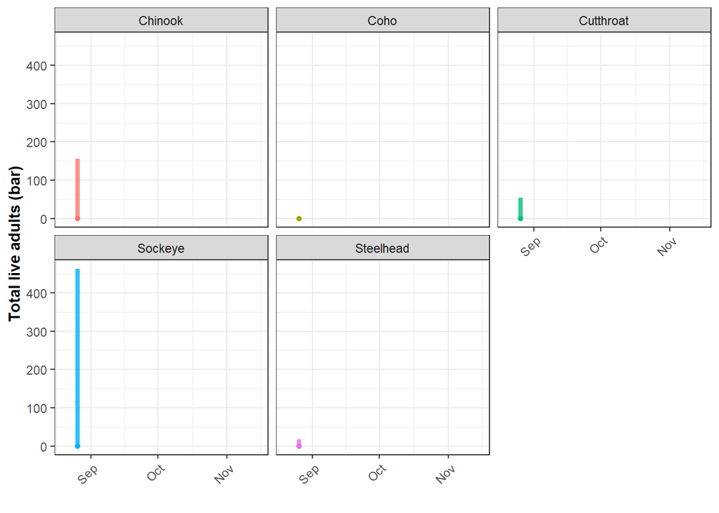

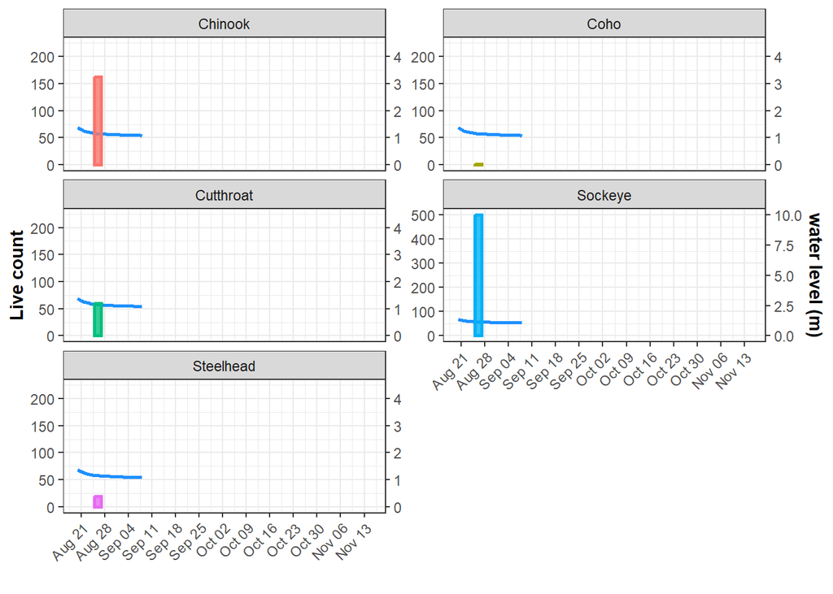

Figure 2.2: Live counts (bars) and water level (blue line) in the Nitinat River.

# 3 **Historical run timing**

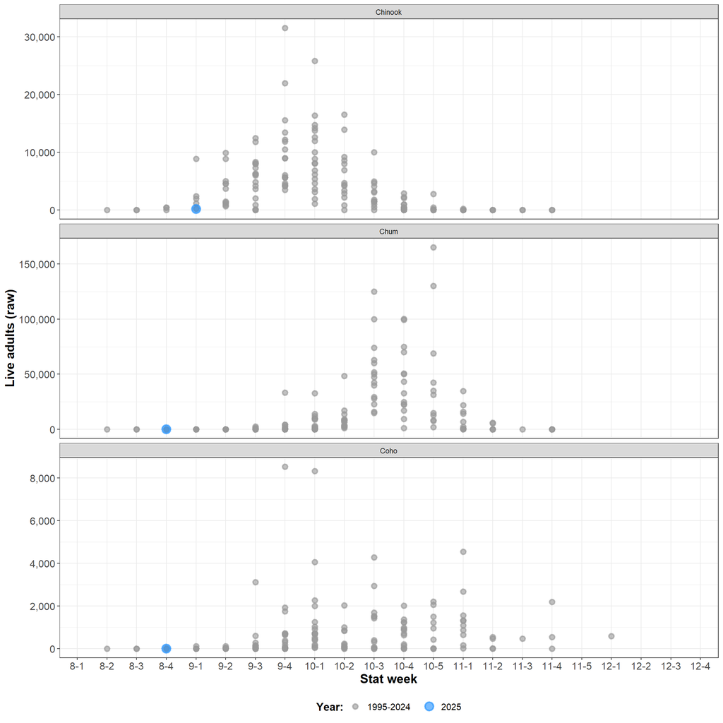

Figure 3.1: Historical run timing for focal species in Nitinat River (gray). Stat weeks along x axis denote the month and week of historical counts (e.g., stat week 8-1=First week of August, statweek 9-3=Third week of Sept, etc). Current year counts will show as blue points when populated.

# 4 **Water level and temperature**

The following water data are compiled from the Nitinat Hydromet operated by South Coast Stock Assessment: http://pacfish.ca/wcviweather/Content%20Pages/Nitinat/WaterLevel.aspx

The hydromet station for Nitinat is not currently reporting to the website. Work is underway to restore reporting before swims begin. For now, the following information is summarized from the backend database. Contact Katie with questions.

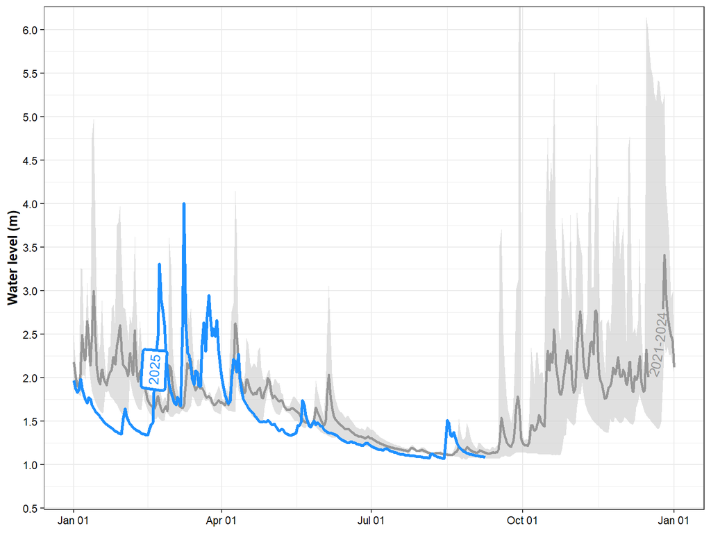

Figure 4.1: Nitinat hydromet water level (m). Historical shaded area represents daily maximum and minimum recorded values over the time series, while the line represents the mean water level. Current year line represents daily mean water level (blue). Water level is recorded hourly at the Nitinat River Hatchery pumphouse.

The last downloaded water level was **1.09 m** on **8-Sep-25** at **12:00 PM**. Current water temp is **14.26 C**, air temp is **20.35 C**.

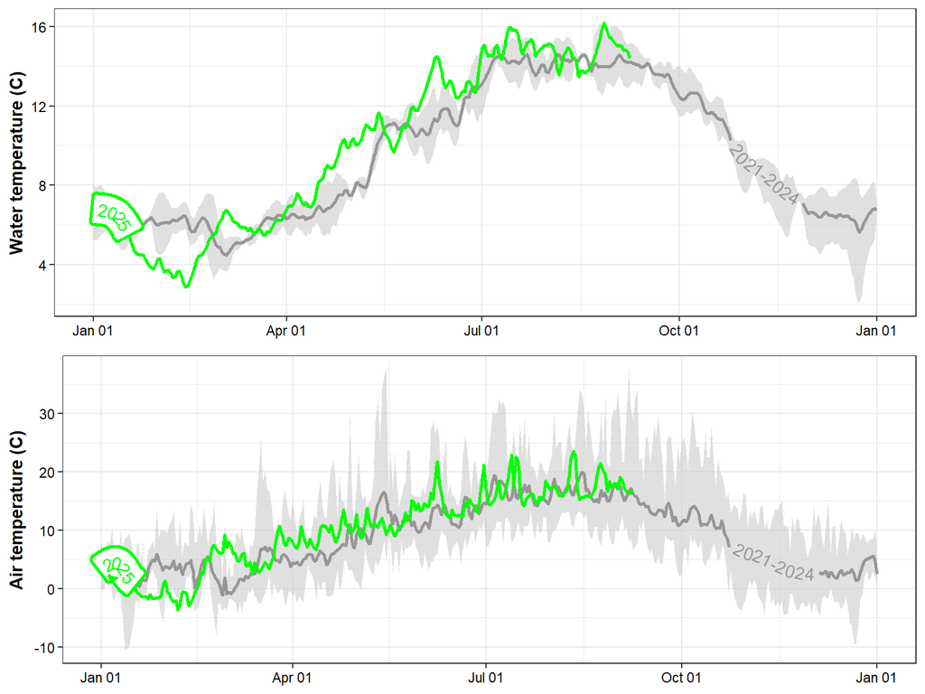

Figure 4.2: Nitinat hydromet water and air temperature (C). Historical shaded area represents daily maximum and minimum recorded values over the time series, while the line represents the mean (gray). Current year line represents daily mean water and/or air temperature (green). Water and air temperature are recorded hourly at the Nitinat River Hatchery pumphouse.

## 4.1 Summer water conditions

Graphs focusing on the lead up to and including peak salmon periods

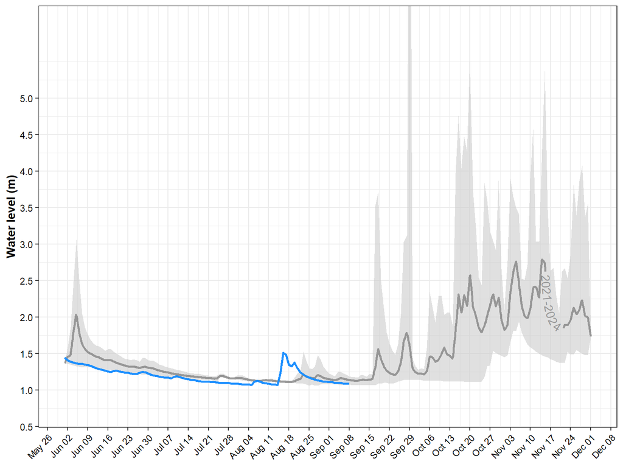

Figure 4.3: Nitinat hydromet water level (m) for summer and fall. Historical shaded area represents daily maximum and minimum recorded values over the time series, while the line represents the mean water level. Current year line represents daily mean water level (blue). Water level is recorded hourly at the Nitinat River Hatchery pumphouse.

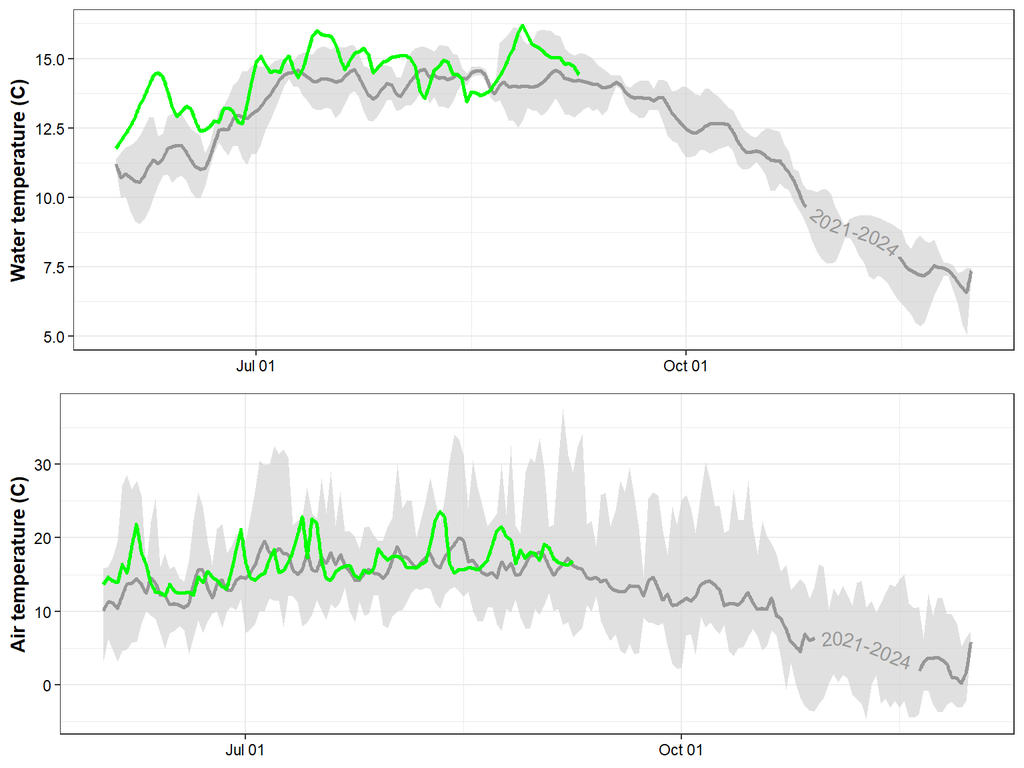

Figure 4.4: Nitinat hydromet water and air temperature (C) for summer and fall. Historical shaded area represents daily maximum and minimum recorded values over the time series, while the line represents the mean (gray). Current year line represents daily mean water and/or air temperature (green). Water and air temperature are recorded hourly at the Nitinat River Hatchery pumphouse.

## 4.2 Environment Canada river forecast

While there is no official flow forecast for the Nitinat River, the San Juan River Environment Canada COFFEE forecast can be used as a proxy for Nitinat River as both systems exhibit similar seasonal flow patterns.

[interactive chart not shown]

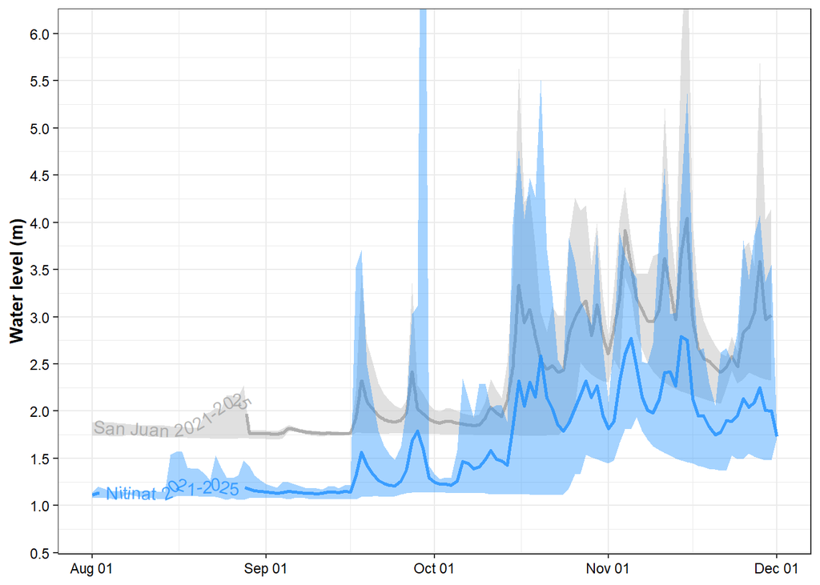

Figure 4.5: Summer/fall water level at Nitinat (blue) and San Juan (gray) from 2021-present. Shaded region represents daily maximum and minimum levels while solid line indicates daily average among all years. San Juan water level from Environment Canada, Nitinat from South Coast Stock assessment hydromet.

## 4.3 Weather forecast

[interactive chart not shown]